# Kenya STEP Skills Dashboard: An Interactive Analysis of Skills, Employment and Earnings in Urban Kenya

- Show All Code
- Hide All Code
- View Source

STA — Data Visualisation and Interactive Analytics Project

Authors

OSEWE RAPHAEL

STEPHEN MARIGA

SUMEIYA DIME

Published

May 28, 2026

Abstract

This report presents the development of an interactive Shiny dashboard for analysing the World Bank STEP (Skills Toward Employability and Productivity) datasets for Kenya. Two complementary surveys are used: the STEP Household Survey (2013, n = 3,894) and the STEP Employer Survey (2016, n = 504), both covering urban Kenya. The dashboard comprises five interactive tabs addressing labour market overview, skills supply, skills demand, the skills gap, and earnings analysis. Key findings include a 29.4% unemployment rate among active workers, a 58.2% informality rate, a 46.2% technical skills gap reported by employers, and a stark wage premium from university education ($10.50/hr) relative to primary-level workers ($1.07/hr). The platform enables policymakers, researchers, and training institutions to explore Kenya’s labour market interactively and identify priority intervention areas.

Keywords

Kenya, STEP survey, skills gap, labour market, Shiny dashboard, interactive visualisation

**NoteGroup Contribution Statement**

| Author | Admission Number | Contribution |
| --- | --- | --- |
| **OSEWE RAPHAEL** | STA3/6170/2023 | 33% |
| **STEPHEN MARIGA** | STA3/4196/2023 | 33% |
| **SUMEIYA DIME** | SAC3/6562/2023 | 33% |

# 1 Introduction

## 1.1 Background

Kenya, like many sub-Saharan African economies, faces a persistent paradox in its labour market: employers report difficulty finding suitably skilled workers, while simultaneously unemployment — particularly among youth — remains alarmingly high. This disconnect between the skills workers possess and the skills employers demand is commonly referred to as the **skills mismatch problem**, and it represents one of the most critical barriers to economic development in the region.

The World Bank’s **Skills Toward Employability and Productivity (STEP)** programme was designed precisely to quantify this problem. STEP surveys measure skills from both sides of the labour market: the **supply side** (workers and households) and the **demand side** (employers and firms). Kenya is one of a small number of African countries with both a STEP Household Survey and a STEP Employer Survey, making it uniquely suited for this kind of cross-survey analysis.

## 1.2 Project Objectives

This project aims to:

1. Acquire and prepare the Kenya STEP datasets for analytical use
2. Develop an **interactive Shiny dashboard** that allows users to explore Kenya’s labour market dynamically
3. Identify and communicate key findings about skills supply, skills demand, and the resulting gap
4. Provide an analytical platform that is contextually relevant to the Kenyan and East African setting

## 1.3 Report Structure

This report proceeds as follows: Section 2 describes the datasets; Section 3 presents the methodology and dashboard architecture; Sections 4–8 present findings from each dashboard tab; Section 9 discusses policy implications; and Section 10 concludes.

# 2 Data Description

## 2.1 Dataset 1: STEP Household Survey (2013)

```r
hh_summary <- data.frame(
  Attribute = c("Survey Name", "Country", "Year", "Coverage",
                "Sample Size", "Unit of Analysis", "Key Themes", "Source"),
  Details   = c(
    "STEP Household Survey",
    "Kenya",
    "2013",
    "Urban areas across all major regions",
    "3,894 respondents (2,041 male, 1,853 female)",
    "Working-age individuals (15–64 years)",
    "Education, employment, wages, literacy, socio-emotional skills",
    "World Bank Microdata Library — Catalog No. 2226"
  )
)

kable(hh_summary, col.names = c("Attribute","Details"),
      caption = "Table 1: STEP Household Survey Overview") |>
  kable_styling(bootstrap_options = c("striped","hover","condensed"),
                full_width = FALSE, font_size = 12) |>
  column_spec(1, bold = TRUE, color = "#38bdf8")
```

Table 1: STEP Household Survey Overview

| Attribute | Details |
| --- | --- |
| Survey Name | STEP Household Survey |
| Country | Kenya |
| Year | 2013 |
| Coverage | Urban areas across all major regions |
| Sample Size | 3,894 respondents (2,041 male, 1,853 female) |
| Unit of Analysis | Working-age individuals (15–64 years) |
| Key Themes | Education, employment, wages, literacy, socio-emotional skills |
| Source | World Bank Microdata Library — Catalog No. 2226 |

The household survey collects data on **3,894 urban Kenyan workers** across 78 districts. It covers the full spectrum of labour market outcomes — from unemployment and informality to cognitive test scores, literacy levels, and the Big-5 personality traits. Crucially, it records hourly earnings in both Kenyan shillings and USD, enabling cross-country comparisons.

### 2.1.1 Key Variables (Household Survey)

```r
hh_vars <- data.frame(
  Variable = c("gender_label","age","educ_group","emp_status",
               "earnings_h_usd","literacy_pct","has_training",
               "read_label","extraversion_av","grit_av"),
  Type     = c("Categorical","Continuous","Ordered Factor","Categorical",
               "Continuous","Continuous","Binary",
               "Ordered Factor","Continuous","Continuous"),
  Description = c(
    "Male / Female",
    "Age in years (range: 15–64)",
    "Education bracket: None to University+",
    "Wage Worker / Informal Wage / Unemployed / Inactive",
    "Hourly earnings in USD (median = $1.63)",
    "ETS literacy test score as % of maximum (36 items)",
    "1 = received vocational or skills training",
    "Literacy level: Cannot Read → Full Passage",
    "Extraversion personality score (scale 1–4)",
    "Grit score — perseverance & consistency (scale 1–4)"
  )
)

kable(hh_vars, col.names = c("Variable","Type","Description"),
      caption = "Table 2: Key Variables — Household Survey") |>
  kable_styling(bootstrap_options = c("striped","hover","condensed"), font_size = 11) |>
  column_spec(1, monospace = TRUE, color = "#4ade80")
```

Table 2: Key Variables — Household Survey

| Variable | Type | Description |
| --- | --- | --- |
| gender_label | Categorical | Male / Female |
| age | Continuous | Age in years (range: 15–64) |
| educ_group | Ordered Factor | Education bracket: None to University+ |
| emp_status | Categorical | Wage Worker / Informal Wage / Unemployed / Inactive |
| earnings_h_usd | Continuous | Hourly earnings in USD (median = $1.63) |
| literacy_pct | Continuous | ETS literacy test score as % of maximum (36 items) |
| has_training | Binary | 1 = received vocational or skills training |
| read_label | Ordered Factor | Literacy level: Cannot Read → Full Passage |
| extraversion_av | Continuous | Extraversion personality score (scale 1–4) |
| grit_av | Continuous | Grit score — perseverance & consistency (scale 1–4) |

## 2.2 Dataset 2: STEP Employer Survey (2016)

```r
emp_summary <- data.frame(
  Attribute = c("Survey Name","Country","Year","Coverage",
                "Sample Size","Unit of Analysis","Key Themes","Source"),
  Details   = c(
    "STEP Employer Survey",
    "Kenya",
    "2016",
    "13 urban areas including Nairobi, Mombasa, Kisumu, Nakuru",
    "504 firms across 18 industry sectors",
    "Formal and semi-formal enterprises",
    "Skills demand, hiring difficulties, training, vacancies, productivity",
    "World Bank Microdata Library — Catalog No. 2996"
  )
)

kable(emp_summary, col.names = c("Attribute","Details"),
      caption = "Table 3: STEP Employer Survey Overview") |>
  kable_styling(bootstrap_options = c("striped","hover","condensed"),
                full_width = FALSE, font_size = 12) |>
  column_spec(1, bold = TRUE, color = "#fb923c")
```

Table 3: STEP Employer Survey Overview

| Attribute | Details |
| --- | --- |
| Survey Name | STEP Employer Survey |
| Country | Kenya |
| Year | 2016 |
| Coverage | 13 urban areas including Nairobi, Mombasa, Kisumu, Nakuru |
| Sample Size | 504 firms across 18 industry sectors |
| Unit of Analysis | Formal and semi-formal enterprises |
| Key Themes | Skills demand, hiring difficulties, training, vacancies, productivity |
| Source | World Bank Microdata Library — Catalog No. 2996 |

The employer survey covers **504 Kenyan firms** spanning micro-enterprises (fewer than 10 employees) to large corporations (200+ employees). It captures employers’ perspectives on the skills their workers possess versus the skills they need — providing the demand-side counterpart to the household survey.

### 2.2.1 Key Variables (Employer Survey)

```r
emp_vars <- data.frame(
  Variable = c("sector_label","size_cat","city",
               "diff_soft","diff_tech",
               "provides_training","has_vacancies","productivity_up"),
  Type     = c("Categorical","Ordered Factor","Categorical",
               "Binary","Binary","Binary","Binary","Binary"),
  Description = c(
    "Industry sector (18 categories)",
    "Firm size: Micro / Small / Medium / Large",
    "Survey city (13 urban areas)",
    "1 = firm reports difficulty finding soft-skilled workers",
    "1 = firm reports difficulty finding technically skilled workers",
    "1 = firm provides on-job or off-job training",
    "1 = firm has unfilled vacancies",
    "1 = firm reports productivity increased in past year"
  )
)

kable(emp_vars, col.names = c("Variable","Type","Description"),
      caption = "Table 4: Key Variables — Employer Survey") |>
  kable_styling(bootstrap_options = c("striped","hover","condensed"), font_size = 11) |>
  column_spec(1, monospace = TRUE, color = "#fb923c")
```

Table 4: Key Variables — Employer Survey

| Variable | Type | Description |
| --- | --- | --- |
| sector_label | Categorical | Industry sector (18 categories) |
| size_cat | Ordered Factor | Firm size: Micro / Small / Medium / Large |
| city | Categorical | Survey city (13 urban areas) |
| diff_soft | Binary | 1 = firm reports difficulty finding soft-skilled workers |
| diff_tech | Binary | 1 = firm reports difficulty finding technically skilled workers |
| provides_training | Binary | 1 = firm provides on-job or off-job training |
| has_vacancies | Binary | 1 = firm has unfilled vacancies |
| productivity_up | Binary | 1 = firm reports productivity increased in past year |

## 2.3 How the Two Datasets Relate

The two surveys cannot be merged at the individual level — they sampled different populations. However, they share **common analytical dimensions** that allow comparative analysis:

- **Geography** — both cover urban Kenya with overlapping city/district coverage
- **Economic sector** — both capture the respondent’s industry
- **Skill categories** — both measure similar skill types from opposite perspectives

This complementarity is exploited in the **Skills Gap tab** of the dashboard, where supply-side worker characteristics are compared to demand-side employer requirements at the sector level.

# 3 Methodology and Dashboard Architecture

## 3.1 Technology Stack

```r
tech <- data.frame(
  Component = c("Dashboard framework","Interactivity","Charts",
                "Data tables","Styling","Data preparation","Language"),
  Tool      = c("shinydashboard","Shiny (reactive programming)","plotly",
                "DT (DataTables)","Custom CSS (dark theme)","dplyr + tidyr","R 4.x")
)
kable(tech, col.names = c("Component","Tool"),
      caption = "Table 5: Technology Stack") |>
  kable_styling(bootstrap_options = c("striped","hover"), full_width = FALSE, font_size = 12)
```

Table 5: Technology Stack

| Component | Tool |
| --- | --- |
| Dashboard framework | shinydashboard |
| Interactivity | Shiny (reactive programming) |
| Charts | plotly |
| Data tables | DT (DataTables) |
| Styling | Custom CSS (dark theme) |
| Data preparation | dplyr + tidyr |
| Language | R 4.x |

## 3.2 Data Preparation Pipeline

The raw data preparation follows a structured pipeline implemented in `data_prep.R`:

```
Raw ZIPs (World Bank)
       ↓  unzip()
Raw CSVs (KEN_Final ES Data.csv, STEP Kenya_working.csv)
       ↓  read_csv()
Raw R data frames
       ↓  transmute() + recode() + case_when()
Cleaned data frames (emp_clean, hh_clean)
       ↓  write_csv()
emp_clean.csv + hh_clean.csv
       ↓  read.csv() in app.R
Dashboard reactive datasets
```

Key recoding decisions made during preparation:

- **Education grouped** into six ordered brackets (None → University+) from continuous years-of-schooling variable
- **Employment status** derived from three binary flags: `wage_worker`, `informal_wage`, `unemployed`
- **Skill difficulty** recoded from Likert scale to binary (1 = difficulty, 0 = no difficulty)
- **Literacy score** expressed as percentage of 36-item ETS test maximum

## 3.3 Dashboard Structure

The dashboard is organised into five thematic tabs, each driven by a specific research question:

```r
tabs <- data.frame(
  Tab = c("1. Overview","2. Skills Supply","3. Skills Demand",
          "4. Skills Gap","5. Earnings Analysis"),
  `Data Source` = c("Both","Household Survey","Employer Survey","Both","Household Survey"),
  `Research Question` = c(
    "What is the overall labour market picture in urban Kenya?",
    "What skills and qualifications do Kenyan workers have?",
    "What skills are Kenyan employers struggling to find?",
    "Where is the mismatch between supply and demand most severe?",
    "What determines wage levels and the gender pay gap?"
  ),
  `Key Charts` = c(
    "KPI cards, employment pie, gender bars, firm sectors",
    "Wage by education, literacy ranking, traits radar",
    "Skill gap by sector, training provision, vacancies",
    "Bubble chart, wage premium table, formal vs informal",
    "Violin plots, occupation bars, gender wage gap lines"
  )
)

kable(tabs, col.names = c("Tab","Data Source","Research Question","Key Charts"),
      caption = "Table 6: Dashboard Tab Structure") |>
  kable_styling(bootstrap_options = c("striped","hover","condensed"), font_size = 10) |>
  column_spec(1, bold = TRUE)
```

Table 6: Dashboard Tab Structure

| Tab | Data Source | Research Question | Key Charts |
| --- | --- | --- | --- |
| 1. Overview | Both | What is the overall labour market picture in urban Kenya? | KPI cards, employment pie, gender bars, firm sectors |
| 2. Skills Supply | Household Survey | What skills and qualifications do Kenyan workers have? | Wage by education, literacy ranking, traits radar |
| 3. Skills Demand | Employer Survey | What skills are Kenyan employers struggling to find? | Skill gap by sector, training provision, vacancies |
| 4. Skills Gap | Both | Where is the mismatch between supply and demand most severe? | Bubble chart, wage premium table, formal vs informal |
| 5. Earnings Analysis | Household Survey | What determines wage levels and the gender pay gap? | Violin plots, occupation bars, gender wage gap lines |

## 3.4 Interactive Features

The dashboard provides the following interactive controls:

- **Global sidebar filters**: Gender, age range (15–64), and education level — all household charts update reactively
- **Skill type toggle**: On the Skills Demand tab, users switch between soft-skill and technical-skill gaps
- **District literacy sorter**: Sort by highest or lowest performing districts; slider controls how many districts are shown
- **Earnings group explorer**: Users select any grouping variable (education, occupation, sector, gender) and the earnings quantile chart rebuilds

# 4 Tab 1: Overview — Labour Market Snapshot

## 4.1 Key Performance Indicators

```r
# Compute KPIs
active   <- hh |> filter(emp_status %in% c("Unemployed","Wage Worker","Informal Wage"))
workers  <- hh |> filter(earnings_h_usd > 0, !is.na(earnings_h_usd))
employed <- hh |> filter(emp_status %in% c("Wage Worker","Informal Wage"))

kpis <- data.frame(
  Indicator = c(
    "Total workers surveyed (HH)", "Total firms surveyed",
    "Unemployment rate (active workers)","Informality rate (employed workers)",
    "Median hourly wage (USD)","Full literacy rate",
    "Firms reporting technical skills gap","Firms providing worker training"
  ),
  Value = c(
    format(nrow(hh), big.mark = ","),
    nrow(emp),
    paste0(round(mean(active$emp_status == "Unemployed") * 100, 1), "%"),
    paste0(round(mean(employed$emp_status == "Informal Wage") * 100, 1), "%"),
    paste0("$", round(median(workers$earnings_h_usd), 2)),
    paste0(round(mean(hh$read_label == "Full Passage", na.rm = TRUE) * 100, 1), "%"),
    paste0(round(mean(emp$diff_tech) * 100, 1), "%"),
    paste0(round(mean(emp$provides_training) * 100, 1), "%")
  ),
  Source = c(rep("HH Survey",6), rep("Employer Survey",2))
)

kable(kpis, col.names = c("Indicator","Value","Source"),
      caption = "Table 7: Dashboard Key Performance Indicators") |>
  kable_styling(bootstrap_options = c("striped","hover"), font_size = 12) |>
  column_spec(2, bold = TRUE, color = "#38bdf8") |>
  row_spec(c(3,4), background = "#1e293b")
```

Table 7: Dashboard Key Performance Indicators

| Indicator | Value | Source |
| --- | --- | --- |
| Total workers surveyed (HH) | 3,894 | HH Survey |
| Total firms surveyed | 504 | HH Survey |
| Unemployment rate (active workers) | 29.4% | HH Survey |
| Informality rate (employed workers) | 58.2% | HH Survey |
| Median hourly wage (USD) | $1.63 | HH Survey |
| Full literacy rate | 38.4% | HH Survey |
| Firms reporting technical skills gap | 46.2% | Employer Survey |
| Firms providing worker training | 79.6% | Employer Survey |

## 4.2 Employment Status Distribution

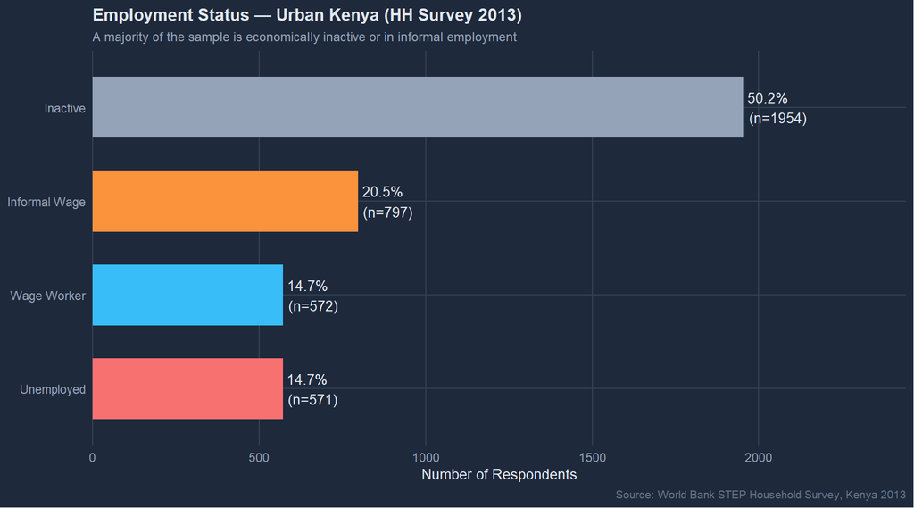

Figure 1: Employment status distribution among surveyed urban Kenyan workers

```r
emp_status_d <- hh |> count(emp_status) |>
  mutate(pct = round(n / sum(n) * 100, 1),
         emp_status = factor(emp_status,
           levels = c("Inactive","Unemployed","Informal Wage","Wage Worker")))

ggplot(emp_status_d, aes(x = reorder(emp_status, n), y = n, fill = emp_status)) +
  geom_col(width = 0.65, show.legend = FALSE) +
  geom_text(aes(label = paste0(pct, "%\n(n=", n, ")")),
            hjust = -0.1, color = "#e2e8f0", size = 3.5) +
  scale_fill_manual(values = c(
    "Inactive"     = "#94a3b8",
    "Unemployed"   = "#f87171",
    "Informal Wage"= "#fb923c",
    "Wage Worker"  = "#38bdf8"
  )) +
  coord_flip(clip = "off") +
  scale_y_continuous(expand = expansion(mult = c(0, 0.25))) +
  labs(title    = "Employment Status — Urban Kenya (HH Survey 2013)",
       subtitle = "A majority of the sample is economically inactive or in informal employment",
       x = NULL, y = "Number of Respondents",
       caption = "Source: World Bank STEP Household Survey, Kenya 2013") +
  theme_step()
```

The most striking finding from the overview is that **formal wage employment accounts for only 14.7% of the sample**. The largest single category is economic inactivity (50.2%), followed by informal wage employment (20.5%) and unemployment (14.7%). Together, unemployment and informality affect a substantial majority of economically active urban Kenyans.

## 4.3 Employment by Gender

[figure not shown]

Figure 2: Employment status by gender, showing percentage within each gender group

```r
gender_emp <- hh |>
  group_by(gender_label, emp_status) |>
  summarise(n = n(), .groups = "drop") |>
  group_by(gender_label) |>
  mutate(pct = round(n / sum(n) * 100, 1))

ggplot(gender_emp, aes(x = gender_label, y = pct,
                        fill = factor(emp_status,
                          levels = c("Inactive","Unemployed","Informal Wage","Wage Worker")))) +
  geom_col(position = "fill", width = 0.55) +
  geom_text(aes(label = paste0(pct, "%")),
            position = position_fill(vjust = 0.5),
            color = "white", size = 3.5, fontface = "bold") +
  scale_y_continuous(labels = percent_format()) +
  scale_fill_manual(
    name   = "Status",
    values = c("Inactive"     = "#64748b",
               "Unemployed"   = "#f87171",
               "Informal Wage"= "#fb923c",
               "Wage Worker"  = "#38bdf8")) +
  labs(title    = "Employment Status by Gender",
       subtitle = "Women are more likely to be inactive; men more likely to be unemployed",
       x = NULL, y = "Share within gender group",
       caption = "Source: World Bank STEP Household Survey, Kenya 2013") +
  theme_step()
```

# 5 Tab 2: Skills Supply — What Workers Bring

## 5.1 Wages by Education Level

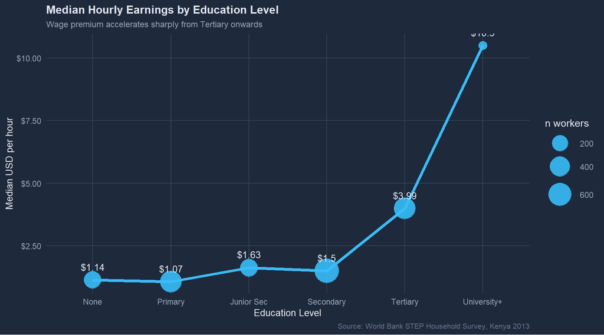

Figure 3: Median hourly earnings (USD) by education level — a clear wage premium emerges at tertiary and university levels

```r
wage_educ <- hh |>
  filter(!is.na(earnings_h_usd), earnings_h_usd > 0, !is.na(educ_group)) |>
  group_by(educ_group) |>
  summarise(median_wage = round(median(earnings_h_usd), 2),
            n           = n(), .groups = "drop")

ggplot(wage_educ, aes(x = educ_group, y = median_wage, group = 1)) +
  geom_line(color = "#38bdf8", linewidth = 1.5) +
  geom_point(aes(size = n), color = "#38bdf8", alpha = 0.9) +
  geom_text(aes(label = paste0("$", median_wage)),
            vjust = -1.3, color = "#e2e8f0", size = 3.5) +
  scale_size_continuous(range = c(4, 12), name = "n workers") +
  scale_y_continuous(labels = dollar_format()) +
  labs(title    = "Median Hourly Earnings by Education Level",
       subtitle = "Wage premium accelerates sharply from Tertiary onwards",
       x = "Education Level", y = "Median USD per hour",
       caption = "Source: World Bank STEP Household Survey, Kenya 2013") +
  theme_step()
```

There is a **clear and steep wage gradient** by education in urban Kenya. Workers with only primary education earn a median of **$1.07 per hour**, while university graduates earn **$10.50 per hour** — nearly ten times as much. Importantly, the wage premium is modest between primary and secondary levels, then jumps sharply at tertiary and university levels, suggesting that **post-secondary credentials carry a substantial labour market premium** in Kenya’s urban economy.

## 5.2 Literacy Performance by District

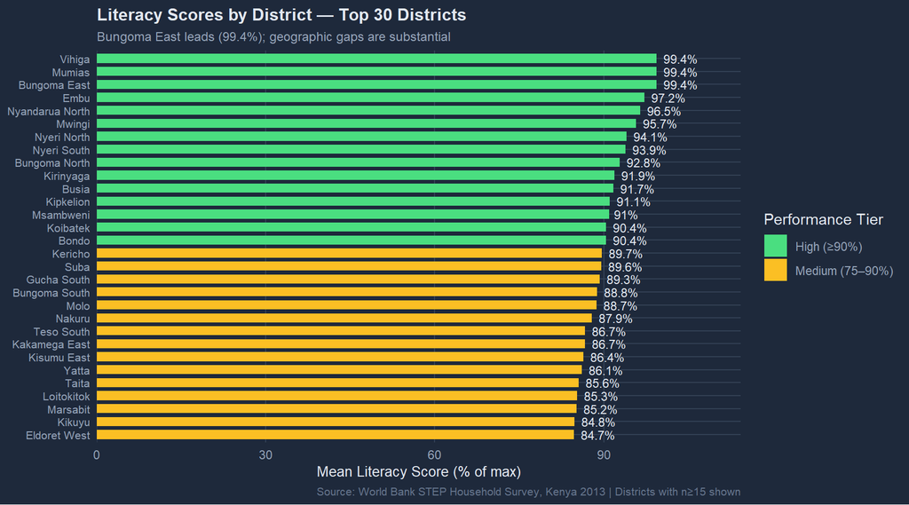

Figure 4: Mean literacy scores (% of ETS maximum) across selected Kenyan districts, coloured by performance tier

```r
lit_district <- hh |>
  group_by(district_clean) |>
  summarise(mean_lit = round(mean(literacy_pct, na.rm = TRUE), 1),
            n = n(), .groups = "drop") |>
  filter(n >= 15) |>
  arrange(desc(mean_lit)) |>
  head(30) |>
  mutate(tier = case_when(
    mean_lit >= 90 ~ "High (≥90%)",
    mean_lit >= 75 ~ "Medium (75–90%)",
    TRUE           ~ "Low (<75%)"
  ))

ggplot(lit_district, aes(x = mean_lit, y = reorder(district_clean, mean_lit), fill = tier)) +
  geom_col(width = 0.7) +
  geom_text(aes(label = paste0(mean_lit, "%")), hjust = -0.2,
            color = "#e2e8f0", size = 3) +
  scale_fill_manual(name = "Performance Tier",
                    values = c("High (≥90%)"    = "#4ade80",
                               "Medium (75–90%)"= "#fbbf24",
                               "Low (<75%)"     = "#f87171")) +
  scale_x_continuous(expand = expansion(mult = c(0, 0.15))) +
  labs(title    = "Literacy Scores by District — Top 30 Districts",
       subtitle = "Bungoma East leads (99.4%); geographic gaps are substantial",
       x = "Mean Literacy Score (% of max)", y = NULL,
       caption = "Source: World Bank STEP Household Survey, Kenya 2013 | Districts with n≥15 shown") +
  theme_step() +
  theme(axis.text.y = element_text(size = 8))
```

# 6 Tab 3: Skills Demand — What Employers Need

## 6.1 Technical Skills Gap by Sector

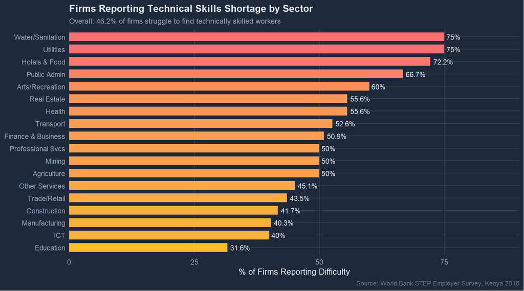

Figure 5: Percentage of firms in each sector reporting difficulty finding technically skilled workers

```r
skill_sec <- emp |>
  group_by(sector_label) |>
  summarise(pct_tech = round(mean(diff_tech) * 100, 1),
            pct_soft = round(mean(diff_soft) * 100, 1),
            n        = n(), .groups = "drop") |>
  arrange(desc(pct_tech))

ggplot(skill_sec, aes(x = pct_tech, y = reorder(sector_label, pct_tech))) +
  geom_col(aes(fill = pct_tech), width = 0.7, show.legend = FALSE) +
  geom_text(aes(label = paste0(pct_tech, "%")), hjust = -0.15,
            color = "#e2e8f0", size = 3) +
  scale_fill_gradient(low = "#fbbf24", high = "#f87171") +
  scale_x_continuous(expand = expansion(mult = c(0, 0.2))) +
  labs(title    = "Firms Reporting Technical Skills Shortage by Sector",
       subtitle = "Overall: 46.2% of firms struggle to find technically skilled workers",
       x = "% of Firms Reporting Difficulty", y = NULL,
       caption = "Source: World Bank STEP Employer Survey, Kenya 2016") +
  theme_step()
```

## 6.2 Training Provision by Firm Size

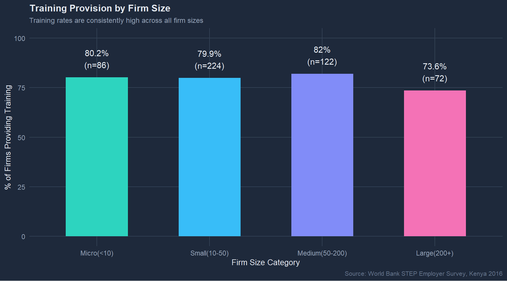

Figure 6: Percentage of firms providing worker training, by firm size category

```r
train_sz <- emp |>
  mutate(size_cat = factor(size_cat, levels = size_levels)) |>
  group_by(size_cat) |>
  summarise(pct = round(mean(provides_training) * 100, 1),
            n   = n(), .groups = "drop")

ggplot(train_sz, aes(x = size_cat, y = pct, fill = size_cat)) +
  geom_col(width = 0.55, show.legend = FALSE) +
  geom_text(aes(label = paste0(pct, "%\n(n=", n, ")")),
            vjust = -0.5, color = "#e2e8f0", size = 3.8) +
  scale_fill_manual(values = c("#2dd4bf","#38bdf8","#818cf8","#f472b6")) +
  scale_y_continuous(limits = c(0, 100)) +
  labs(title    = "Training Provision by Firm Size",
       subtitle = "Training rates are consistently high across all firm sizes",
       x = "Firm Size Category", y = "% of Firms Providing Training",
       caption = "Source: World Bank STEP Employer Survey, Kenya 2016") +
  theme_step()
```

A notably counter-intuitive finding is that **training provision does not strongly differ by firm size**. Even micro-enterprises (fewer than 10 employees) provide training at rates comparable to large firms. This suggests that the **persistent skills gap is a structural problem** — not simply a result of small firms being unable to afford training — and may reflect misalignment between training content and employer needs.

# 7 Tab 4: Skills Gap — Supply Meets Demand

## 7.1 Formal vs. Informal Wage Comparison

[figure not shown]

Figure 7: Median hourly wages comparing formal wage workers and informal wage workers by sector

```r
formal_d <- hh |>
  filter(emp_status %in% c("Wage Worker","Informal Wage"),
         !is.na(earnings_h_usd), earnings_h_usd > 0,
         sector_label != "Unknown") |>
  group_by(sector_label, emp_status) |>
  summarise(median_wage = round(median(earnings_h_usd), 2), .groups = "drop")

ggplot(formal_d, aes(x = sector_label, y = median_wage, fill = emp_status)) +
  geom_col(position = "dodge", width = 0.65) +
  geom_text(aes(label = paste0("$", median_wage)),
            position = position_dodge(width = 0.65),
            vjust = -0.5, color = "#e2e8f0", size = 3) +
  scale_fill_manual(name   = "Employment Type",
                    values = c("Wage Worker"   = "#38bdf8",
                               "Informal Wage" = "#fb923c")) +
  scale_y_continuous(labels = dollar_format(), limits = c(0, 6)) +
  labs(title    = "Formal vs Informal Median Wages by Sector",
       subtitle = "Formal workers consistently earn more; the gap is largest in Services",
       x = NULL, y = "Median Hourly Wage (USD)",
       caption = "Source: World Bank STEP Household Survey, Kenya 2013") +
  theme_step() +
  theme(axis.text.x = element_text(angle = 30, hjust = 1))
```

## 7.2 Education–Skills–Employment Summary

```r
gap_tbl <- hh |>
  filter(!is.na(educ_group)) |>
  group_by(educ_group) |>
  summarise(
    N                   = n(),
    `Employment %`      = round(mean(emp_status %in% c("Wage Worker","Informal Wage")) * 100, 1),
    `Formal Work %`     = round(mean(emp_status == "Wage Worker") * 100, 1),
    `Median Wage (USD/hr)` = round(median(earnings_h_usd[earnings_h_usd > 0], na.rm = TRUE), 2),
    `Training %`        = round(mean(has_training, na.rm = TRUE) * 100, 1),
    `Literacy %`        = round(mean(literacy_pct, na.rm = TRUE), 1),
    .groups = "drop"
  ) |>
  arrange(educ_group)

kable(gap_tbl,
      caption = "Table 8: Education Level vs Key Labour Market Outcomes") |>
  kable_styling(bootstrap_options = c("striped","hover","condensed"), font_size = 11) |>
  column_spec(5, bold = TRUE, color = "#38bdf8") |>
  column_spec(7, color = "#4ade80")
```

Table 8: Education Level vs Key Labour Market Outcomes

| educ_group | N | Employment % | Formal Work % | Median Wage (USD/hr) | Training % | Literacy % |
| --- | --- | --- | --- | --- | --- | --- |
| None | 462 | 26.2 | 2.4 | 1.14 | 2.6 | 31.4 |
| Primary | 881 | 31.1 | 4.9 | 1.07 | 3.9 | 76.3 |
| Junior Sec | 545 | 28.8 | 10.1 | 1.63 | 6.4 | 89.0 |
| Secondary | 1241 | 33.2 | 13.5 | 1.50 | 10.8 | 85.4 |
| Tertiary | 698 | 52.1 | 37.7 | 3.99 | 25.8 | 92.6 |
| University+ | 41 | 68.3 | 61.0 | 10.50 | 58.5 | 92.4 |

# 8 Tab 5: Earnings Analysis

## 8.1 Gender Wage Gap

[figure not shown]

```r
earn_eg <- hh |>
  filter(!is.na(earnings_h_usd), earnings_h_usd > 0, !is.na(educ_group)) |>
  group_by(educ_group, gender_label) |>
  summarise(median_wage = round(median(earnings_h_usd), 2), .groups = "drop")

ggplot(earn_eg, aes(x = educ_group, y = median_wage,
                     color = gender_label, group = gender_label)) +
  geom_line(linewidth = 1.8) +
  geom_point(size = 5) +
  geom_text(aes(label = paste0("$", median_wage)),
            vjust = -1.2, size = 3.2, fontface = "bold") +
  scale_color_manual(name   = "Gender",
                     values = c("Male" = "#38bdf8", "Female" = "#f472b6")) +
  scale_y_continuous(labels = dollar_format(), limits = c(0, 14)) +
  labs(title    = "Median Hourly Wages by Education Level and Gender",
       subtitle = "The gender gap widens dramatically at university level",
       x = "Education Level", y = "Median USD per Hour",
       caption = "Source: World Bank STEP Household Survey, Kenya 2013") +
  theme_step() +
  theme(axis.text.x = element_text(angle = 20, hjust = 1))
```

## 8.2 Wages by Occupation

[figure not shown]

Figure 9: Median hourly wage by occupation category with interquartile range bars

```r
occ_wage <- hh |>
  filter(!is.na(earnings_h_usd), earnings_h_usd > 0, !is.na(occ_label)) |>
  group_by(occ_label) |>
  summarise(median = round(median(earnings_h_usd), 2),
            q25    = round(quantile(earnings_h_usd, 0.25), 2),
            q75    = round(quantile(earnings_h_usd, 0.75), 2),
            n      = n(), .groups = "drop") |>
  arrange(median)

ggplot(occ_wage, aes(x = median, y = reorder(occ_label, median))) +
  geom_segment(aes(x = q25, xend = q75, yend = occ_label),
               color = "#334155", linewidth = 3, alpha = 0.8) +
  geom_point(aes(size = n), color = "#818cf8", alpha = 0.95) +
  geom_text(aes(label = paste0("$", median)), hjust = -0.6,
            color = "#e2e8f0", size = 3.2) +
  scale_size_continuous(range = c(3, 10), name = "n workers") +
  scale_x_continuous(labels = dollar_format(),
                     expand = expansion(mult = c(0, 0.3))) +
  labs(title    = "Hourly Wages by Occupation (Median + IQR)",
       subtitle = "Managers and Professionals earn 5–10× more than Elementary workers",
       x = "Hourly Wage (USD) — bar shows interquartile range",
       y = NULL,
       caption = "Source: World Bank STEP Household Survey, Kenya 2013") +
  theme_step()
```

# 9 Key Findings and Discussion

## 9.1 Summary of Findings

Drawing together evidence across all five dashboard tabs, the following key findings emerge:

**1. Informality dominates urban Kenya’s labour market.** With 58.2% of employed workers in informal arrangements and only 14.7% in formal wage employment, the informal sector is the primary absorber of urban labour. This has significant implications for social protection, tax revenue, and skills development.

**2. Education generates substantial but non-linear wage returns.** The wage premium is modest between primary and secondary education but accelerates sharply at tertiary and university levels. A university graduate earns approximately 9.8 times the hourly wage of a primary-educated worker. This finding underscores the economic imperative of expanding access to post-secondary education in Kenya.

**3. A persistent technical skills gap afflicts Kenyan employers.** 46.2% of firms report difficulty finding technically skilled workers, and 63.5% have unfilled vacancies. This gap exists despite 79.6% of firms providing training — indicating that the skills mismatch is structural and cannot be resolved by employer training alone.

**5. Geographic inequality in literacy is stark.** A 47-percentage-point gap in mean literacy scores separates the highest-performing district (Bungoma East, 99.4%) from the lowest-performing (Githunguri, 52.0%). This variation likely reflects differences in school quality, teacher availability, and household income across districts.

## 9.2 Policy Implications

# 10 Conclusion

This project successfully developed a five-tab interactive Shiny dashboard integrating the World Bank STEP Household and Employer Surveys for Kenya. The platform provides a comprehensive, filterable view of Kenya’s urban labour market — enabling users to explore employment patterns, skills supply and demand, geographic disparities, and earnings dynamics interactively.

The interactive nature of the dashboard — powered by Shiny’s reactive programming model — transforms static survey data into a dynamic policy analysis tool that researchers, policymakers, and training institutions can use to identify priority interventions and monitor labour market trends over time.

**TipAppendix: Running the Dashboard**

To reproduce this analysis, place `app.R`, `data_prep.R`, `install_packages.R`, and both World Bank ZIP files in the same RStudio project folder, then run:

```r
source("install_packages.R")  # run once
source("data_prep.R")          # run once
shiny::runApp()                # launch dashboard
```